# ARTF-TPM - Project Deviations Report

CRLP

28 July, 2025

## Current Deviation Status

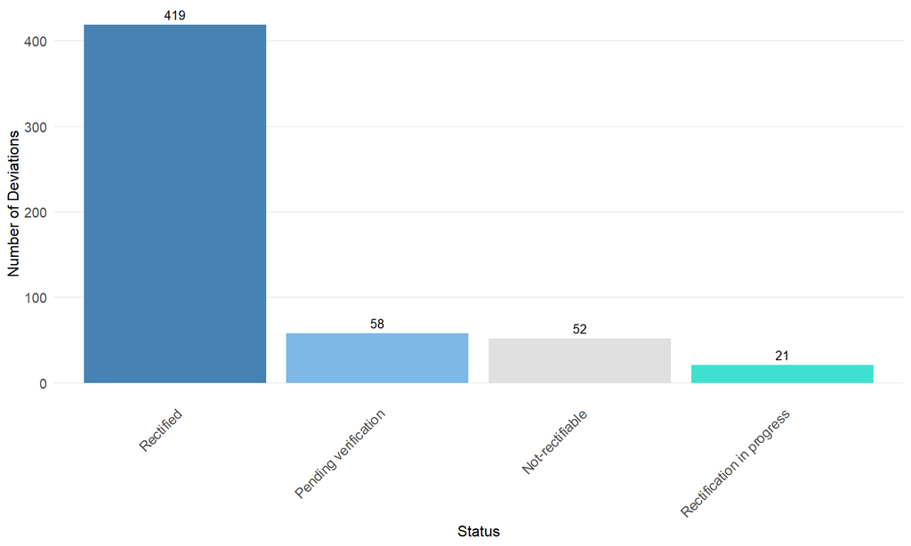

|  | Status | Count | Percentage (%) |
| --- | --- | --- | --- |
| 1 | Rectified | 419 | 76.2 |
| 2 | Pending verification | 58 | 10.5 |
| 3 | Not-rectifiable | 52 | 9.5 |
| 4 | Rectification in progress | 21 | 3.8 |

## Deviation Type

**Click here to view Deviation Type definitions**

**Minor Deviations** - Capable of being rectified within the existing budget and/or timeframe for completion - No significant negative impact in terms of overall structural quality, functionality, and/or sustainability - Not capable of being rectified but has no negative effect on the agreed budget and timeframe for completion.

**Major Deviations** - Capable of being rectified but not within the existing budget and/or timeframe for completion - A significant negative impact in terms of overall structural quality, functionality, and/or sustainability - Not capable of being rectified and resulting in the agreed budget and timeframe for completion being exceeded - Part of the sub-project is non-operational due to recoverable/non-recoverable issues - Failure to construct the part of the sub-project on-site.

**Critical Deviations** - Failure to construct infrastructure in a way that risks the safety or lives of workers or community members during construction and requires urgent mitigation before work can continue - For completed infrastructure, failure to construct infrastructure in a way that is likely to risk the safety or lives of community members or users - A non-recoverable negative impact in terms of structural quality, functionality, or sustainability - Sub-project is non-operational due to recoverable/non-recoverable issues - Failure to construct the sub-project or part of the sub-project on-site.

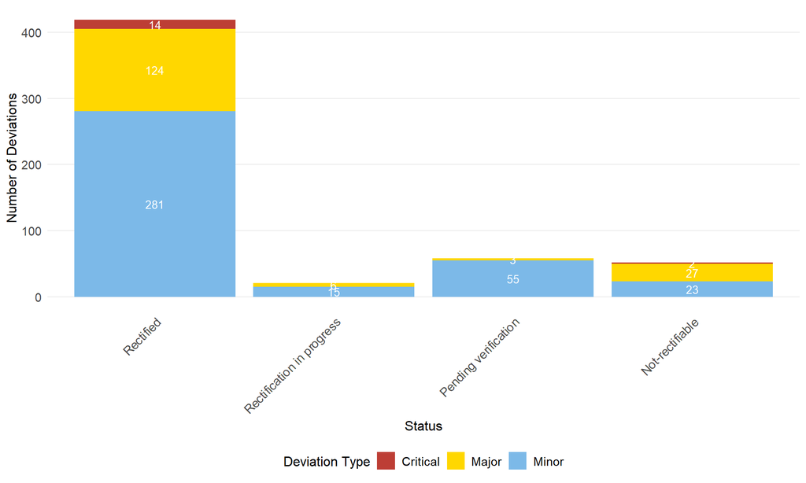

|  | Deviation Type | Status | Count | % of Type | % of Total |
| --- | --- | --- | --- | --- | --- |
| 1 | Critical | Not-rectifiable | 2 | 12.5 | 0.4 |
| 2 | Critical | Rectified | 14 | 87.5 | 2.5 |
| 3 | Major | Not-rectifiable | 27 | 16.9 | 4.9 |
| 4 | Major | Pending verification | 3 | 1.9 | 0.5 |
| 5 | Major | Rectification in progress | 6 | 3.8 | 1.1 |
| 6 | Major | Rectified | 124 | 77.5 | 22.5 |
| 7 | Minor | Not-rectifiable | 23 | 6.1 | 4.2 |
| 8 | Minor | Pending verification | 55 | 14.7 | 10 |
| 9 | Minor | Rectification in progress | 15 | 4 | 2.7 |
| 10 | Minor | Rectified | 281 | 75.1 | 51.1 |

## Deviation Aspect Type

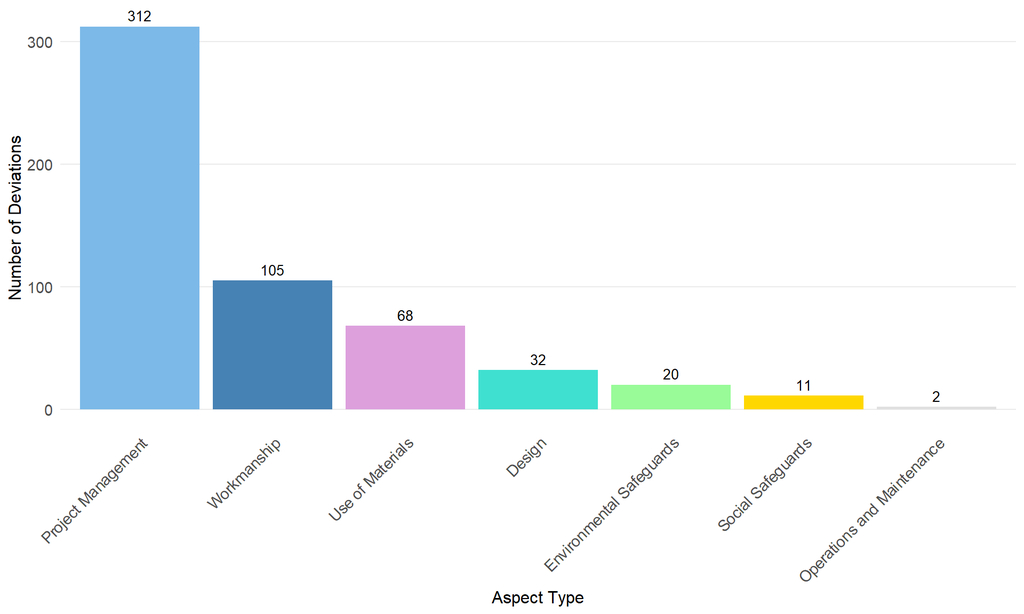

|  | Aspect Type | Count | Percentage (%) |
| --- | --- | --- | --- |
| 1 | Project Management | 312 | 56.7 |
| 2 | Workmanship | 105 | 19.1 |
| 3 | Use of Materials | 68 | 12.4 |
| 4 | Design | 32 | 5.8 |
| 5 | Environmental Safeguards | 20 | 3.6 |
| 6 | Social Safeguards | 11 | 2 |
| 7 | Operations and Maintenance | 2 | 0.4 |

## Monthly Trend Analysis

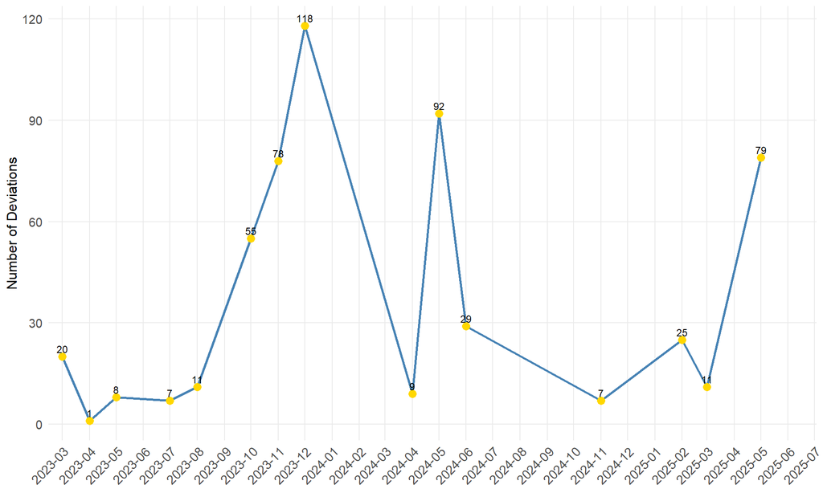

## Deviation Status Over Time

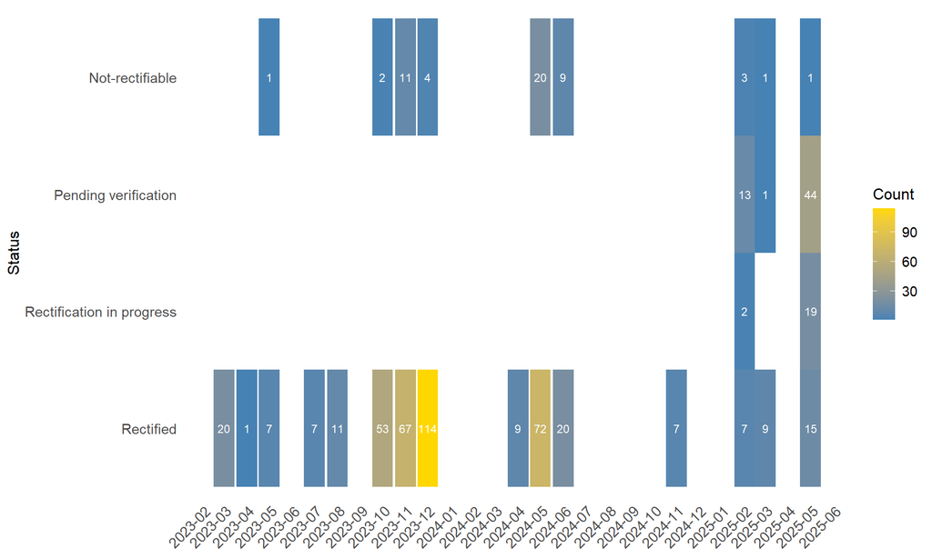

## Detailed Monthly Summary

|  | Year | Month | Status | Count | % of Month Total |
| --- | --- | --- | --- | --- | --- |
| 1 | 2023 | Mar | Rectified | 20 | 100 |
| 2 | 2023 | Apr | Rectified | 1 | 100 |
| 3 | 2023 | May | Not-rectifiable | 1 | 12.5 |
| 4 | 2023 | May | Rectified | 7 | 87.5 |
| 5 | 2023 | Jul | Rectified | 7 | 100 |
| 6 | 2023 | Aug | Rectified | 11 | 100 |
| 7 | 2023 | Oct | Not-rectifiable | 2 | 3.6 |
| 8 | 2023 | Oct | Rectified | 53 | 96.4 |
| 9 | 2023 | Nov | Not-rectifiable | 11 | 14.1 |
| 10 | 2023 | Nov | Rectified | 67 | 85.9 |

[output cut: 19 more lines]

## Deviation Type Analysis by Month

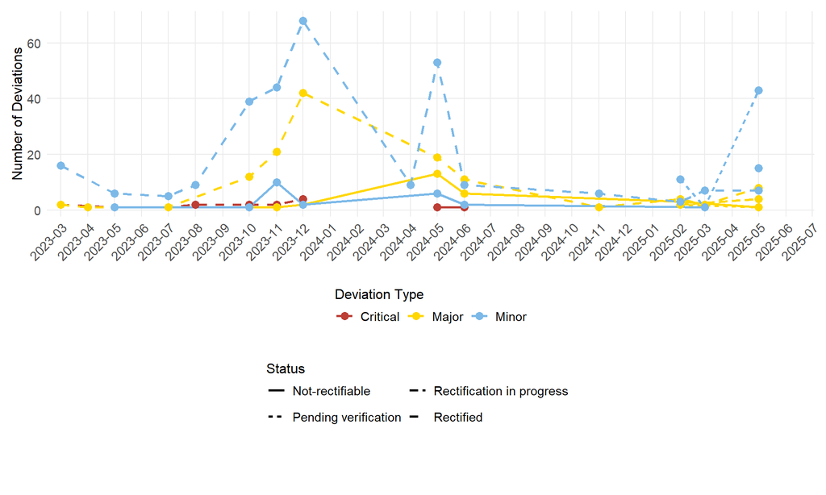

## Deviation Type Over Time

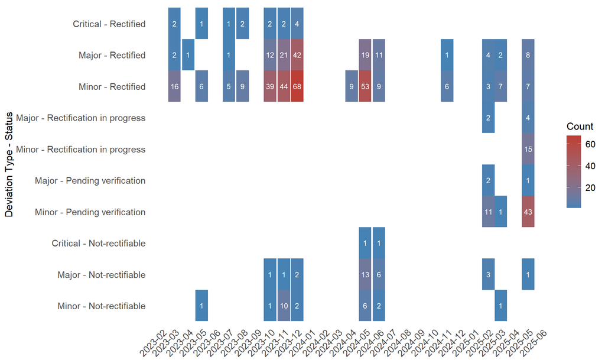

## Detailed Deviation Type Summary by Month

|  | Year | Month | Deviation Type | Status | Count | % of Month Total |
| --- | --- | --- | --- | --- | --- | --- |
| 1 | 2023 | Mar | Critical | Rectified | 2 | 10 |
| 2 | 2023 | Mar | Major | Rectified | 2 | 10 |
| 3 | 2023 | Mar | Minor | Rectified | 16 | 80 |
| 4 | 2023 | Apr | Major | Rectified | 1 | 100 |
| 5 | 2023 | May | Critical | Rectified | 1 | 12.5 |
| 6 | 2023 | May | Minor | Not-rectifiable | 1 | 12.5 |
| 7 | 2023 | May | Minor | Rectified | 6 | 75 |
| 8 | 2023 | Jul | Critical | Rectified | 1 | 14.3 |
| 9 | 2023 | Jul | Major | Rectified | 1 | 14.3 |
| 10 | 2023 | Jul | Minor | Rectified | 5 | 71.4 |

[output cut: 47 more lines]